# Red Wine Analysis by Swetha Ganapathi Raman

# Multivariate Plots Section

### Alcohol, Volatile acidity and Quality rating

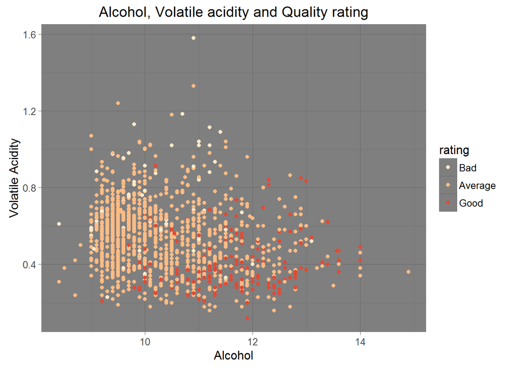

Here we have a plot that shows wines with higher quality being in the lower right of the plot. We can infer that higher quality wines tend to have high alcohol percentage and low volatile acidity.

### Sulphates, Alcohol and Quality rating

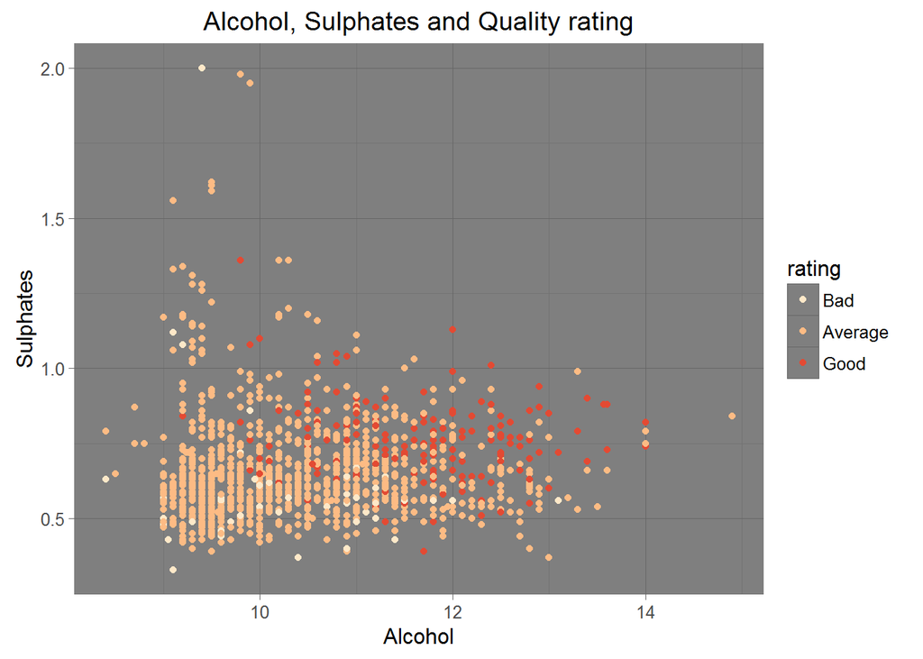

We notice that the high quality wines are placed in top right corner of the plot with higher level of sulphates and alcohol.

# Citric acid, Alcohol and Quality rating

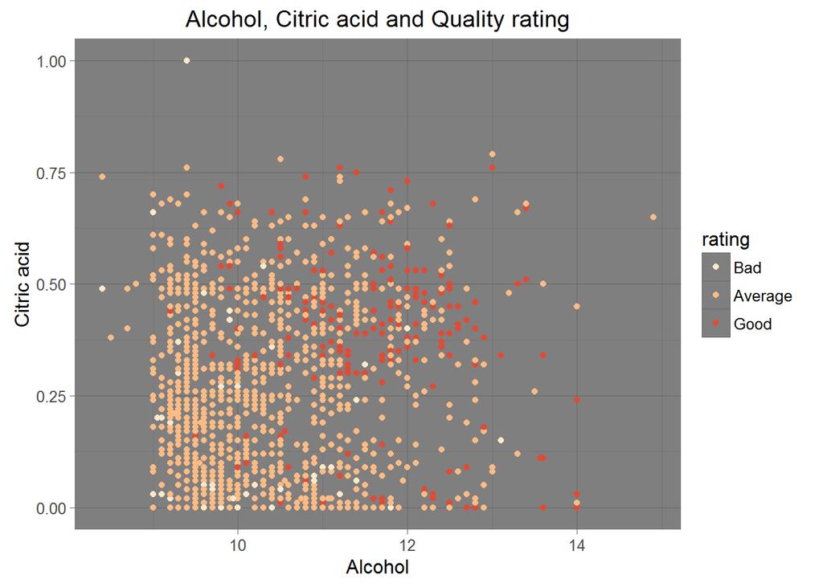

Good quality wines have a higher alcohol value and a citric value typically more than 0.25

### Sulphates, Volatile acidity, Quality rating

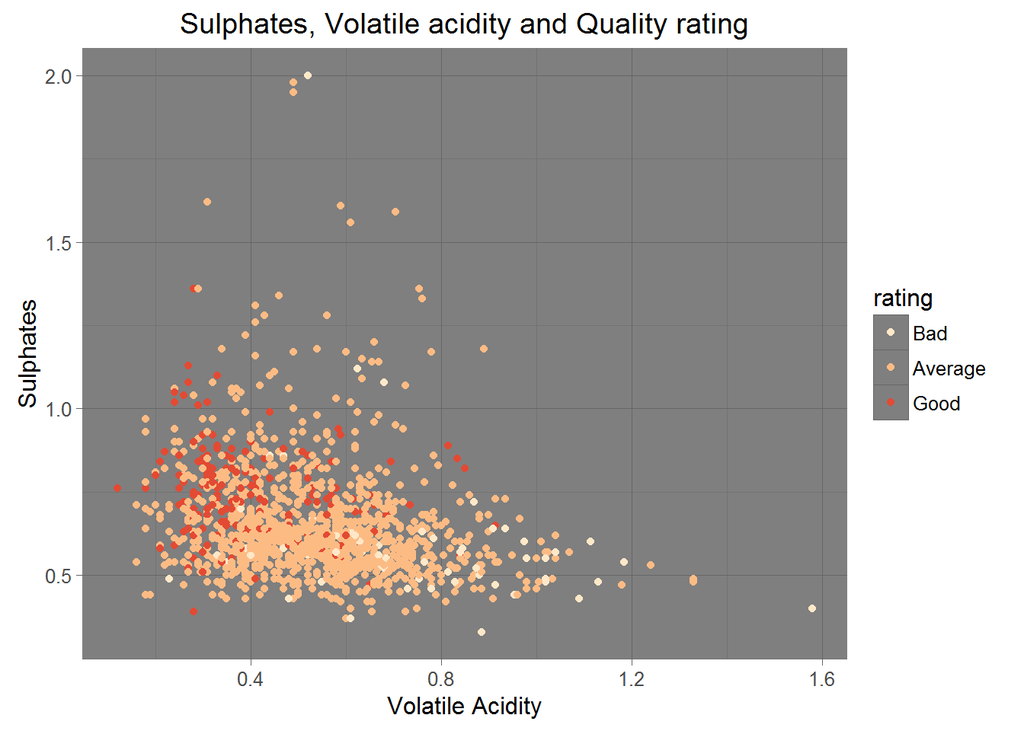

Good quality wines typically have volatile acidity less than 0.4

### Alcohol, density, quality rating

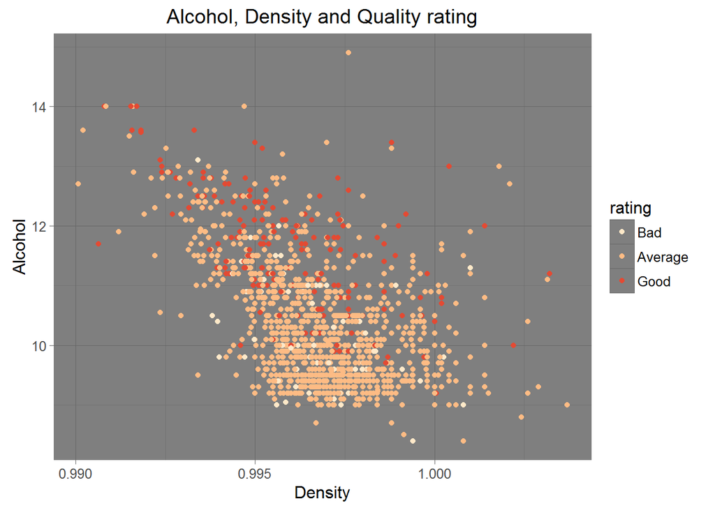

There does not seem to be any siginificant difference in density values between good quality and other wines.

# Multivariate Analysis

### Talk about some of the relationships you observed in this part of the investigation. Were there features that strengthened each other in terms of looking at your feature(s) of interest? Were there any interesting or surprising interactions between features?

At end of bivariate analysis, I determined the most correlated features with quality are alcohol, volatile acidity, citric acid and suplhates. Hence, in this section I focused on them.

Red Wine seems to have better quality when volatile acidity is around 0.3 and alcohol is between 11 and 13. Wines with quality 5 occurs the most when volatile acidity is between 0.4 and 0.8 and alcohol is between 8 and 10. Wines have lower quality when volatile acidity is 0.8 or higher.

Most of the good quality wines had citric acid values from 0.25 to 0.75

Also, majority of the good quality wines has suplhate values less than 1.0 and volatile acidity below 0.4

# Final Plots and Summary

### Plot One

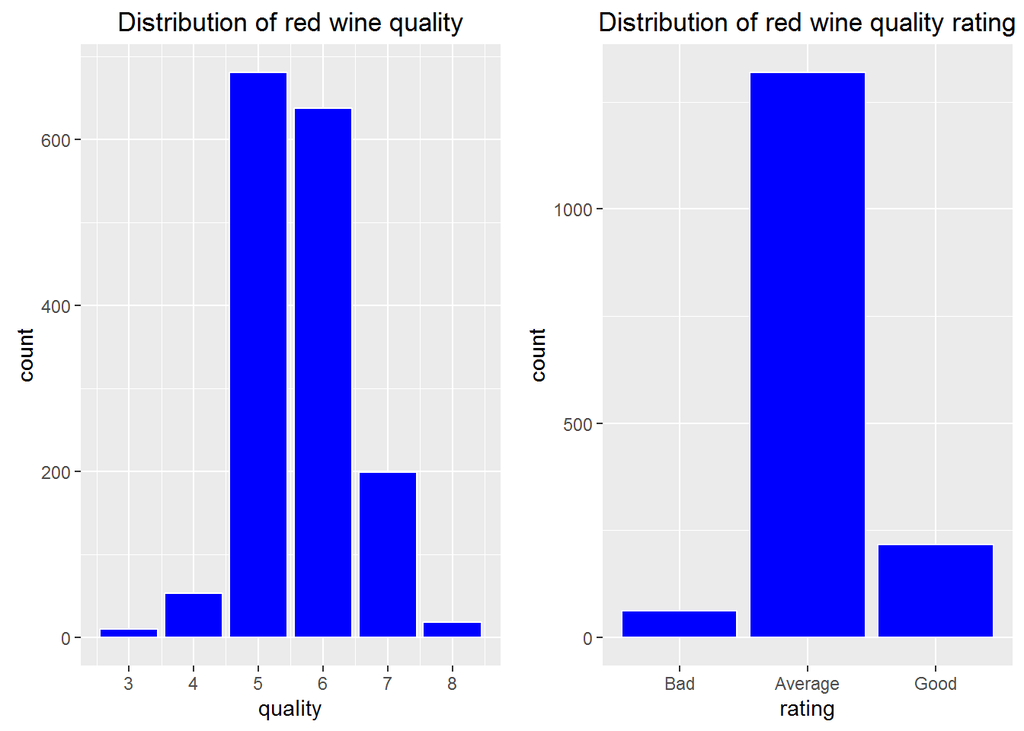

### Description One

The distribution of the red wine appears to be normal. Majority of the red wines in the dataset are Average quality (5 or 6). Approximately one eights of the wines have a quality 7. There are no wines with quality less than 3 or greater than 8 in this dataset.

### Plot Two

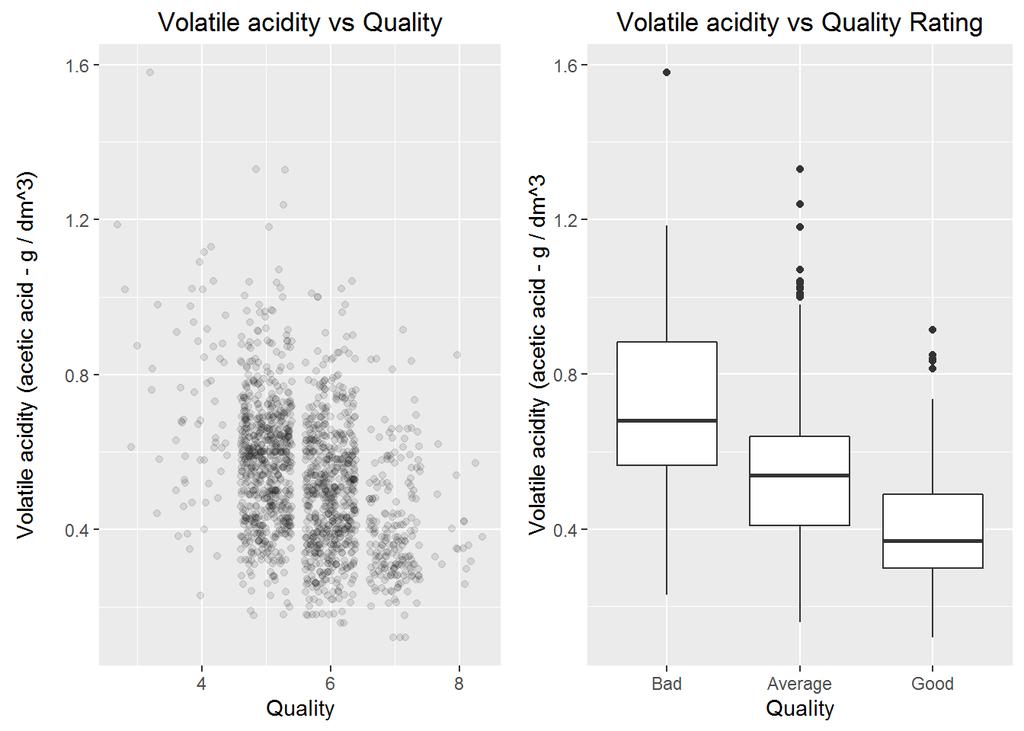

### Description Two

Volatile acidity is a key feature that determines red wine quality. Volatile acidity is negatively correlated with quality with a correlation coefficient of -0.39

Red wines with the lowest volatile acidity have the best quality.

### Plot Three

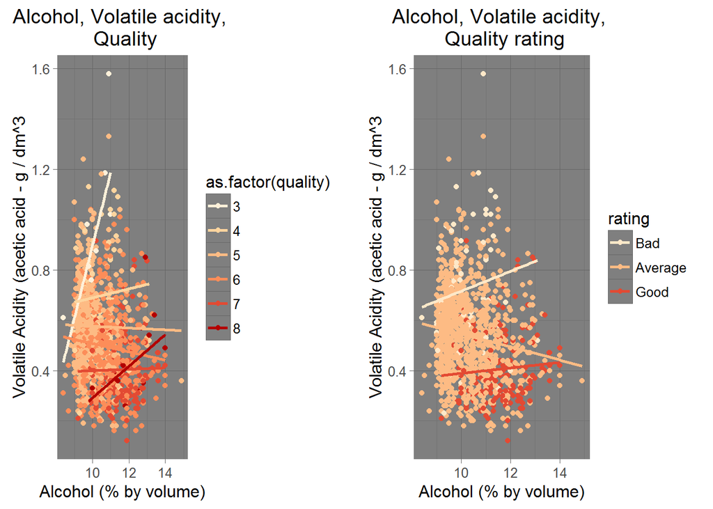

### Description Three

Alcohol is another feature that determines the red wine quality.

We also inferred this from the correlation matrix. Alcohol and quality are positively correlated with a correlation coefficient of 0.47. Volatile acidity and quality are negatively correlated with a correlation coefficient of -0.39.

Wines with higher quality are in the lower right of the plot and we can infer that higher quality wines tend to have high alcohol percentage and low volatile acidity.

# Reflection

This data set contains information on 1,599 different red wines. My objective was to determine which of the features in the dataset affected the Quality of red wine. I started out by understanding the individual variables in the dataset by plotting their histograms. I looked for any unusual behaviors in the histograms.

From my analysis, I determined that high quality red wines have lower volatile acidity and higher alcohol, citric acid and sulphates.

During the analysis, some of the struggles I faced were setting parameters on some R functions like ggplot. Further reading up on these functions helped me understand. Also, I had difficulty coming up with a model for predicting the wine quality. I would like to do some more studying on the modeling and do this for further work on this project.

Also, for further investigation, I will be curious to see if I can get the price information on these red wines and determine if price and quality are correlated. Also, I would be interested in seeing if the quality of white wines will also have a similar pattern.